# RDS_T5_heatmaps

### Choosing Data

```r
packageDescription('airway')
```

```
## Package: airway
## Title: RangedSummarizedExperiment for RNA-Seq in airway smooth muscle
##         cells, by Himes et al PLoS One 2014
## Version: 1.28.0
## Author: Michael Love
## Maintainer: Michael Love <michaelisaiahlove@gmail.com>
## Description: This package provides a RangedSummarizedExperiment object
##         of read counts in genes for an RNA-Seq experiment on four human
##         airway smooth muscle cell lines treated with dexamethasone.
##         Details on the gene model and read counting procedure are
##         provided in the package vignette. The citation for the
##         experiment is: Himes BE, Jiang X, Wagner P, Hu R, Wang Q,
##         Klanderman B, Whitaker RM, Duan Q, Lasky-Su J, Nikolos C,
##         Jester W, Johnson M, Panettieri R Jr, Tantisira KG, Weiss ST,
##         Lu Q. 'RNA-Seq Transcriptome Profiling Identifies CRISPLD2 as a
##         Glucocorticoid Responsive Gene that Modulates Cytokine Function
##         in Airway Smooth Muscle Cells.' PLoS One. 2014 Jun
##         13;9(6):e99625. PMID: 24926665. GEO: GSE52778.
## biocViews: ExperimentData, SequencingData, RNASeqData, GEO
## License: LGPL
## Depends: R (>= 3.5.0), SummarizedExperiment
## Suggests: knitr, GEOquery, markdown
## VignetteBuilder: knitr
## git_url: https://git.bioconductor.org/packages/airway
## git_branch: RELEASE_3_21
## git_last_commit: 4896ff2
## git_last_commit_date: 2025-04-15
## Repository: Bioconductor 3.21
## Date/Publication: 2025-04-17
## NeedsCompilation: no
## Packaged: 2025-04-17 15:08:23 UTC; biocbuild
## Built: R 4.5.1; ; 2025-09-03 11:55:38 UTC; unix
##
## -- File: /usr/local/lib/R/site-library/airway/Meta/package.rds
```

Load the data into the environment using data:

```r
data(airway, package="airway")
class(airway)
```

```
## [1] "RangedSummarizedExperiment"
## attr(,"package")
## [1] "SummarizedExperiment"
```

airway Obj is a *SummarizedExperiment* Obj To work with this sort of data structure, we need *SummarizedExperiment* package *SummarizedExperiment* objects can contain multiple ‘assays’ for the same set of genes/transcripts etc. These are accessible with the assays() method. Here we’ve only got the one matrix to deal with. Let’s extract it from the object for ease of use

```r
library(SummarizedExperiment)
assays(airway)
```

```
## List of length 1
## names(1): counts
```

```r
expression <- assays(airway)[[1]]
head(expression)
```

```
##                 SRR1039508 SRR1039509 SRR1039512 SRR1039513 SRR1039516
## ENSG00000000003        679        448        873        408       1138
## ENSG00000000005          0          0          0          0          0
## ENSG00000000419        467        515        621        365        587
## ENSG00000000457        260        211        263        164        245
## ENSG00000000460         60         55         40         35         78
## ENSG00000000938          0          0          2          0          1
##                 SRR1039517 SRR1039520 SRR1039521
## ENSG00000000003       1047        770        572
## ENSG00000000005          0          0          0
## ENSG00000000419        799        417        508
## ENSG00000000457        331        233        229
## ENSG00000000460         63         76         60
## ENSG00000000938          0          0          0
```

```r
nrow(expression) # Number of rows
```

```
## [1] 63677
```

If we try to make a heatmap from this many rows it will be too large to display, so we’re going to need to subset this matrix. The most interesting things are likely to be those that vary the most across samples. We can calculate the variance for each row in the matrix, and select the top 50 most variable rows.

```r
variances <- apply(expression, 1, var)
expression <- expression[order(variances, decreasing=TRUE)[1:50],]
head(expression)
```

```
##                 SRR1039508 SRR1039509 SRR1039512 SRR1039513 SRR1039516
## ENSG00000166923     126514      64824     156189      59216     247345
## ENSG00000115414     260262     213986     513766     273878     252667
## ENSG00000011465     219586     191767     422752     214062     293318
## ENSG00000198804     210138     213952     265361     169551     397791
## ENSG00000115461      74051      79611     328753     137165     241640
## ENSG00000087086     236805     138524     236361      95045     343728
##                 SRR1039517 SRR1039520 SRR1039521
## ENSG00000166923     336864      98504      56549
## ENSG00000115414     399841     345651     370450
## ENSG00000011465     313112     378834     372489
## ENSG00000198804     401539     233051     248032
## ENSG00000115461     216484     145858     148389
## ENSG00000087086     229323     167067     114257
```

### Annotation

For display purposes the Ensembl genes here aren’t all that useful. Where gene symbols are available, let’s add them onto the labels. We’ll use the *org.Hs.eg annotation* package

```r
library(org.Hs.eg.db)
annotation <- merge(toTable(org.Hs.egSYMBOL), toTable(org.Hs.egENSEMBL2EG))
gene_names <- annotation$symbol[match(rownames(expression), annotation$ensembl_id)]
rownames(expression)[! is.na(gene_names)] <- paste(gene_names[!is.na(gene_names)], rownames(expression)[! is.na(gene_names)], sep = ' / ')
```

We’ll be needing some information about what these samples are. We can extract that from our *SummarizedExperiment* with *colData()*. Note that what *colData()* returns is not a regular *data.frame*, hence the use of *data.frame()* to make one.

```r
experiment <- data.frame(colData(airway))
head(experiment)
```

```
##            SampleName    cell   dex albut        Run avgLength Experiment
## SRR1039508 GSM1275862  N61311 untrt untrt SRR1039508       126  SRX384345
## SRR1039509 GSM1275863  N61311   trt untrt SRR1039509       126  SRX384346
## SRR1039512 GSM1275866 N052611 untrt untrt SRR1039512       126  SRX384349
## SRR1039513 GSM1275867 N052611   trt untrt SRR1039513        87  SRX384350
## SRR1039516 GSM1275870 N080611 untrt untrt SRR1039516       120  SRX384353
## SRR1039517 GSM1275871 N080611   trt untrt SRR1039517       126  SRX384354
##               Sample    BioSample
## SRR1039508 SRS508568 SAMN02422669
## SRR1039509 SRS508567 SAMN02422675
## SRR1039512 SRS508571 SAMN02422678
## SRR1039513 SRS508572 SAMN02422670
## SRR1039516 SRS508575 SAMN02422682
## SRR1039517 SRS508576 SAMN02422673
```

## Heatmaps

Going to use *pheatmap()*, so need to load the package

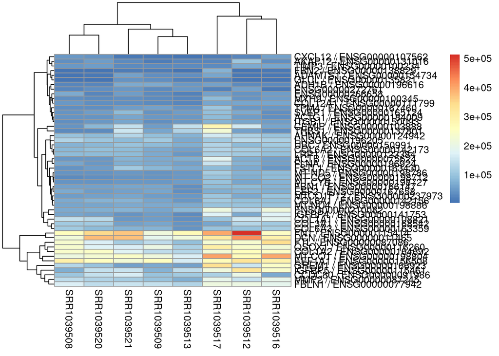

```r
library(pheatmap)
pheatmap(expression)
```

You may find the fonts are difficult to read on the rows so you can adjust this using

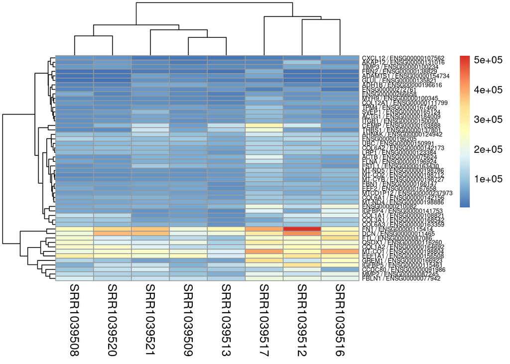

```r
pheatmap(
  expression,
  fontsize_row = 6,
  fontsize_col=12
)
```

Hmm, those colours aren’t all that useful. We’re probably more interested in doublings of expression than more subtle changes, so let’s flip our values to the log2 scale and try again. We’ll need an offset to prevent nasty NA errors in R when log2 is applied to 0 values.

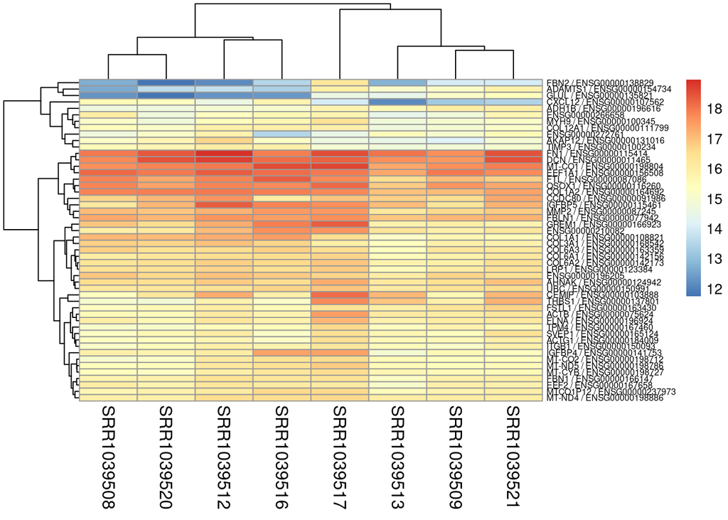

```r
expression <- log2(expression + 1)
pheatmap(
  expression,
  fontsize_row = 6,
  fontsize_col=12
)
```

We’re getting there, but this is still not all that useful. See how the colour range varies between rows? That’s because the different rows vary within different limits, and the colour scale goes from the lowest to highest value anywhere in the matrix. What we really want to highlight is changes within each row.

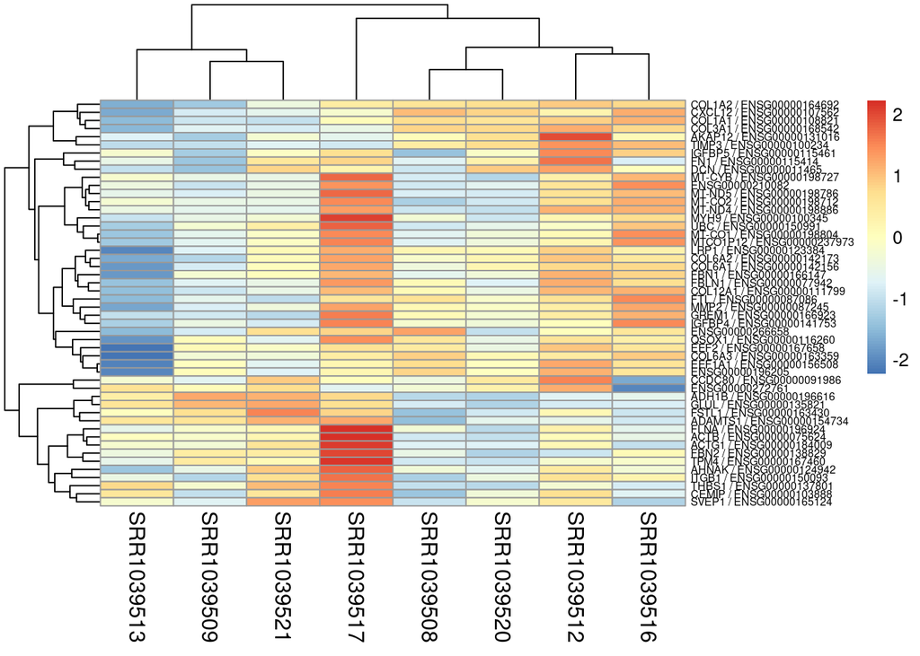

```r
pheatmap(
  expression,
  scale='row',
  fontsize_row = 6,
  fontsize_col=12
)
```

Now we can see the patterns by row. But we don’t know if those patterns have anything to do with the experimental variables. We’ve got our experiment object- can we use that?

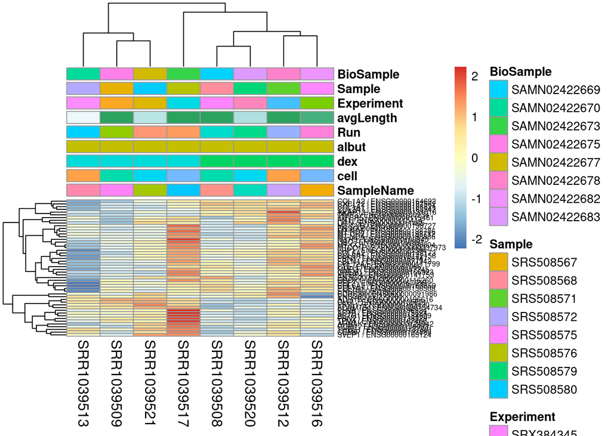

```r
pheatmap(
  expression,
  scale='row',
  annotation_col=experiment,
  fontsize_row = 6,
  fontsize_col=12
)
```

Not many of the group annotations are very useful. SampleName, Experiment etc don’t really represent groups. cell line (cell) and dexamethasone treatment (dex) are probably the only useful variables to examine for groups.

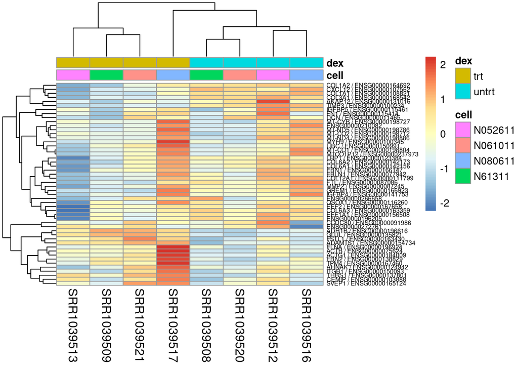

```r
pheatmap(
  expression,
  scale='row',
  annotation_col=experiment[, c('cell', 'dex')],
  fontsize_row = 6,
  fontsize_col=12
)
```

Much better. Plus, the clustering pheatmap() does by default shows us that things cluster mainly by the dex variable. But the sample ordering imposed makes interpretation of cell between dex groups a bit difficult. Look at the documentation again, and you’ll see we can disable that.

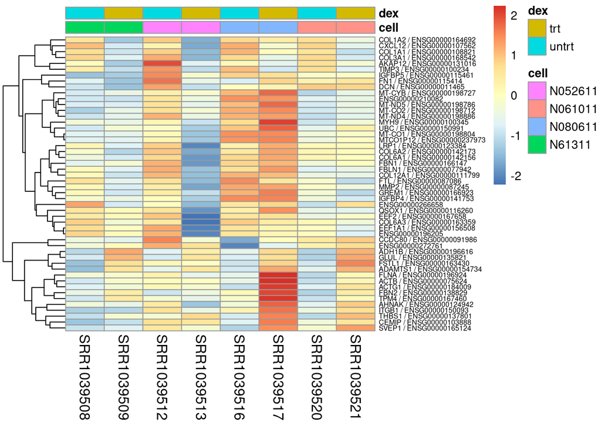

```r
pheatmap(
  expression,
  scale='row',
  annotation_col=experiment[, c('cell', 'dex')],
  cluster_col=FALSE,
  fontsize_row = 6,
  fontsize_col=12
)
```

That’s not an improvement - we need to fix the ordering in our experiment and adjust the expression matrix to match. This sorts by dex, and then by cell.

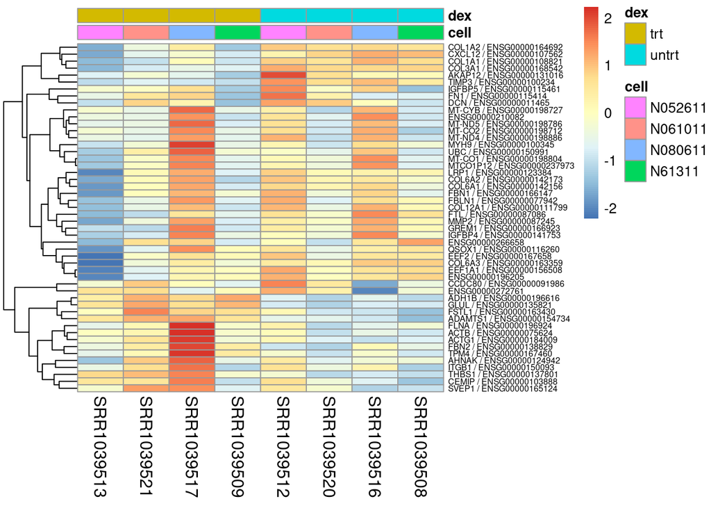

```r
experiment <- experiment[with(experiment, order(dex, cell)), ]
expression <- expression[,rownames(experiment)]

pheatmap(
  expression,
  scale='row',
  annotation_col=experiment[, c('cell', 'dex')],
  cluster_col=FALSE,
  fontsize_row = 6,
  fontsize_col=12
)
```

Those colours aren’t very helpful are they? The two of the cell groups are not very distinguishable. Fortunately we can change the colours.

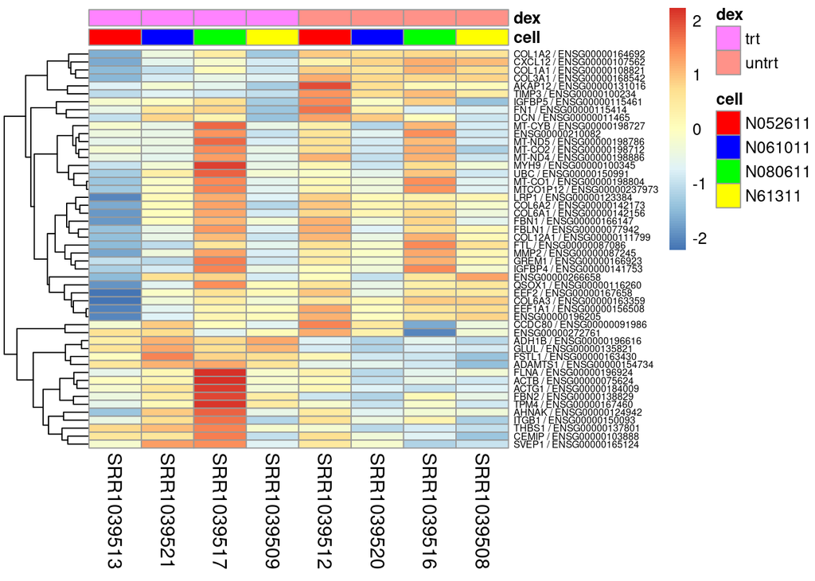

```r
pheatmap(
  expression,
  scale='row',
  annotation_col=experiment[,c('cell', 'dex')],
  cluster_col=FALSE,
  annotation_colors = list('cell' = c('N052611' = 'red', 'N061011' = 'blue', 'N080611' = 'green', 'N61311' = 'yellow')),
  fontsize_row = 6,
  fontsize_col = 12
)
```

### Tidying Up

Add a title Remove the legend (the values associated with colours are meaningless with row scaling)

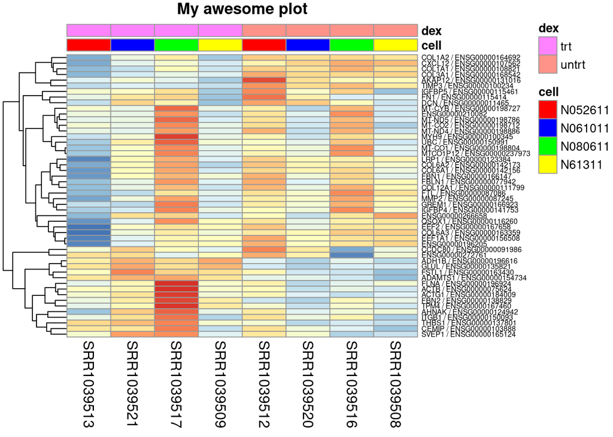

```r
pheatmap(
  expression,
  scale='row',
  annotation_col=experiment[,c('cell', 'dex')],
  cluster_col=FALSE,
  annotation_colors = list('cell' = c('N052611' = 'red', 'N061011' = 'blue', 'N080611' = 'green', 'N61311' = 'yellow')),
  main = 'My awesome plot',
  legend = FALSE,
  fontsize_row = 6,
  fontsize_col = 12
)
```